# Identification of Factors Associcated with Diabetes in the USA

Mercy Atuahene

February 19, 2025

## 1. Introduction

Missing data is common in all kinds of datasets and a persistent problem in statistical analyses. They have the potential to significantly impact the quality and reliability of analysis. See [Book Chapter on Missing Data](https://bookdown.org/mike/data_analysis/imputation-missing-data.html). For instance, in most statistical procedures, sample size may be reduced when records with missing data on certain variables involved in the analysis are removed based on the models of the procedures which can lead to unreliable parameter estimates. Imputation is generally used to handle missing data by replacing missing values with likely values based on the data. Several reasons are responsible for missing data including participants not responding to questions, equipment for data collection issues, poorly structured questionnaires, social desirability issues, etc. Understanding why and how missing data comes about in any analysis is critical to guiding researchers choose the best statistical methods in handling them.

Missing data is often classified into 3 main groups of mechanism of occurrence. They are:

- **Missing at Random (MAR)**: In this mechanism, the missing data is related to the observed data but not the unobserved or missing data. Thus, the probability of that a value is missing depends on other variables in the analysis dataset that has observed values of other variables but not related to the value of the missing data. It assumes that the observed data provides enough information to describe the missing. In this type of missing data, we can handle the missing data through imputation methods such as multiple imputation (MI), maximum likelihood estimation (MLE) as they can account for the data patterns to minimize the impact of the missing values because the data is not completely missing at random.
- **Missing Completely at Random (MCAR)**: This occurs when the missingness is unrelated to the observed or non-missing data and unobserved data. In this type of missing data, no bias will be introduced into the analysis by the missing data and the missing values may be ignored in the analysis or simple approach to replacing them with an imputed value will not introduce bias.
- **Missing Not at Random (MNAR)**: In this type of missing data, the missingness is related to the unobserved data. It is the most challenging type of missing data because of this. If this type of missing data is ignored, it can introduce bias in statistical model estimates and invalid results. In this type of missing data, the missingness often must be modeled posing challenges to data analysis. Traditional approached to handling missing data as in the case of MAR and MCAR do not apply in the case of MNAR.

As stated above, imputation is generally used to address missing data. Some of the ways used to handle missing data via imputation are:

**Single value imputation** like mean/mode/median imputation where the mode is often applicable to categorical data. This method though easy has the potential to distort relationships in the data and reduce variability. For categorical variables, the mode is one way used to replace missing values. Alternative to the mode is using k-nearest neighbors algorithm to impute missing values.

**Likelihood based imputation**: These rely on the likelihood function to estimate the missing values. Examples include Expectation Maximization (EM), Multiple imputation, Bayesian approaches, Full Information Maximum Likelihood (FIML), outcome regression, etc.

**Multiple Imputation**: This approach is based on regression models to predict the missing values through the process of creating multiple complete datasets and then combining the results from each in an effort to account for uncertainty associated with the missing values. These approaches are considered the preferred methods for handling missing data.

In choosing an effective approach to handling missing data, the following are recommended as the guiding principles – techniques that ensure that parameter estimates are unbiased particularly in MAR and MNAR missingness, methods that preserve the statistical power (detecting an effect if one exists- reducing the risk of Type II errors where a true effect is missed) and enables robust hypothesis testing (reliable methods even when certain assumptions are violated) and model estimation and those that accurately estimates standard errors for reliable p-values and confidence intervals. Methods like single imputation underestimate standard errors and lead to overconfident conclusions.

### 1.1 Introduction - Feature Engineering

```r
# get data into R
ddat <- read.csv("https://matuahene.github.io/STA552/Week%202/diabetes_binary_health_indicators_BRFSS2015.csv", skip=0)

#remove duplicates basedd on all columns
df_clean <- ddat[!duplicated(ddat), ]

dups<-ddat[duplicated(ddat), ]
#View(dups)
#nrow(ddat)
#nrow(df_clean)

ddat2 <-df_clean

ddat2$Income_num <- ddat2$Income



# assign meaningful labels to Age
ddat2$Age <- factor(ddat2$Age,
  levels = 1:13,
  labels = c("18-24", "25-29", "30-34", "35-39", "40-44",
             "45-49", "50-54", "55-59", "60-64", "65-69",
             "70-74", "75-79", "80+"))


# BMI categories
ddat2 <- ddat2 %>%
  mutate(BMI_Cat = cut(BMI,
                            breaks = c(0, 18.5, 24.9, 29.9, Inf),
                            labels = c("Underweight", "Normal", "Overweight", "Obese")))
#table( ddat2$BMI_Cat )



# YES/NO labels
ddat2 <- ddat2 %>%
  mutate(
    HighChol = recode(HighChol, "0" = "No", "1" = "Yes"),
    HighBP = recode(HighBP, "0" = "No", "1" = "Yes"),
    Smoker = recode(Smoker, "0" = "No", "1" = "Yes"),
    Stroke = recode(Stroke, "0" = "No", "1" = "Yes"),
    HeartDiseaseorAttack = recode(HeartDiseaseorAttack, "0" = "No", "1" = "Yes"),
    PhysActivity = recode(PhysActivity, "0" = "No", "1" = "Yes"),
    Fruits = recode(Fruits, "0" = "No", "1" = "Yes"),
    Veggies = recode(Veggies, "0" = "No", "1" = "Yes")
  )

#Diabetes status, Education and Income, etc labels
ddat2 <- ddat2 %>%
  mutate(
    Education = recode(Education,
                       "1" = "No High School",
                       "2" = "Some High School",
                       "3" = "High School Graduate",
                       "4" = "Some College",
                       "5" = "College Graduate",
                       "6" = "College 4 years or more (College graduate)"),
    Income = recode(Income,
                    "1" = "<$10K",
                    "2" = "$10K-$15K",
                    "3" = "$15K-$25K",
                    "4" = "$25K-$35K",
                    "5" = "$35K-$50K",
                    "6" = "$50K-$75K",
                    "7" = ">$75K",
                    "8" = ">$75K",
                    .default = "Unknown"),


   Sex = recode(Sex,
                  "1" = "Male",
                  "0" = "Female",
                .default = "Unknown"),
   CholCheck = recode(CholCheck,
                      "1" = "Yes",
                      "0" = "No" ),

   DiffWalk = recode(DiffWalk,
                      "1" = "Yes",
                      "0" = "No" ),

   AnyHealthcare = recode(AnyHealthcare,
                      "1" = "Yes",
                      "0" = "No" ),

   NoDocbcCost = recode(NoDocbcCost,
                      "1" = "Yes",
                      "0" = "No" ),
  HvyAlcoholConsump = recode(HvyAlcoholConsump,
                      "1" = "Yes",
                      "0" = "No" ),
    Diabetes_binary = recode(Diabetes_binary,
                            "0" = "No Diabetes",
                            "1" = "Has Diabetes"),

  GenHlth = recode(GenHlth,
                  "1" = "Excellent",
                   "2" = "Very Good",
                   "3" = "Good",
                   "4" = "Fair",
                   "5" = "Poor",
                   .default = "Unknown")
  )


nonemiss_dat<-ddat2


ddat2$Education <- factor(ddat2$Education, levels = c("No High School", "Some High School", "High School Graduate", "Some College" ,"College Graduate"))

ddat2$Income <- factor(ddat2$Income, levels=c("<$10K", "$10K-$15K", "$15K-$25K", "$25K-$35K", "$35K-$50K", "$50K-$75K", ">$75K"))




#table (ddat2$Income)
#unique(ddat2$Income)

# create some missing data points
# Define the percentage of missing values
missing_percentage <- 0.05

# Get total number of rows
total_rows <- nrow(ddat2)

# Apply missing values to all variables
ddat2 <- ddat2 %>%
  mutate(across(everything(), ~ {
    miss_id <- sample(1:total_rows, size = round(missing_percentage * total_rows), replace = FALSE)
    .[miss_id] <- NA  # Assign NA to selected rows
    .
  }))

# overall summary of variables
#dfSummary(ddat2)

#missing values data
misingdat <- ddat2
forMICE <- ddat2 # reserve data for MICE imputation



#General Health binning
ddat2$GenHlth_bin <- case_when(
  ddat2$GenHlth %in% c("Poor", "Fair") ~ "Fair",
  ddat2$GenHlth %in% c("Good", "Very Good", "Excellent") ~ "Good",
  TRUE ~ "Unknown"
)

# order factors
ddat2$GenHlth_bin <- factor(ddat2$GenHlth_bin, levels = c("Fair", "Good", "Unknown"))



# Categorize income variable
ddat2 <- ddat2 %>%
  mutate(Income_Quartile = ntile(Income_num, 4),  # Divide into 4 quartiles
         Income_q = case_when(
           Income_Quartile == 1 ~ "Low",
           Income_Quartile == 2 ~ "Medium-Low",
           Income_Quartile == 3 ~ "Medium-High",
           Income_Quartile == 4 ~ "High"
         ))


ddat2$Income_q <- factor(ddat2$Income_q, levels = c("Low", "Medium-Low", "Medium-High", "High"))
#table(ddat2$Income_q)


#regroup age
ddat2$Age_grp <- case_when(
  ddat2$Age %in% c("18-24", "25-29", "30-34", "35-39", "40-44") ~ "Younger",
  ddat2$Age %in% c("45-49",  "50-54", "55-59", "60-64") ~ "Middle Age",
  ddat2$Age %in% c("65-69", "70-74", "75-79", "80+") ~ "Older",
  TRUE ~ "Unknown"
)

# Convert the Age_grp variable to a factor and set the levels in the desired order
ddat2$Age_grp <- factor(ddat2$Age_grp, levels = c("Younger", "Middle Age", "Older", "Unknown"))
#table(ddat2$Age , ddat2$Age_grp )
#table( ddat2$Age_grp)

#regroup education
ddat2$Education_cat <- case_when(
  ddat2$Education %in% c("No High School","Some High School" , "High School Graduate",  "Some College"  ) ~ "No College",
  ddat2$Education %in% c("College Graduate") ~ "College Graduate"
  #TRUE ~ "Unknown"
)

ddat2$Education_cat <- factor(ddat2$Education_cat, levels = c("No College", "College Graduate"))

#table(ddat2$Age , ddat2$Age_grp )
#table( ddat2$Education_cat, useNA = "ifany")
#table( ddat2$Education, useNA = "ifany")
```

## 2. Feature Transforming

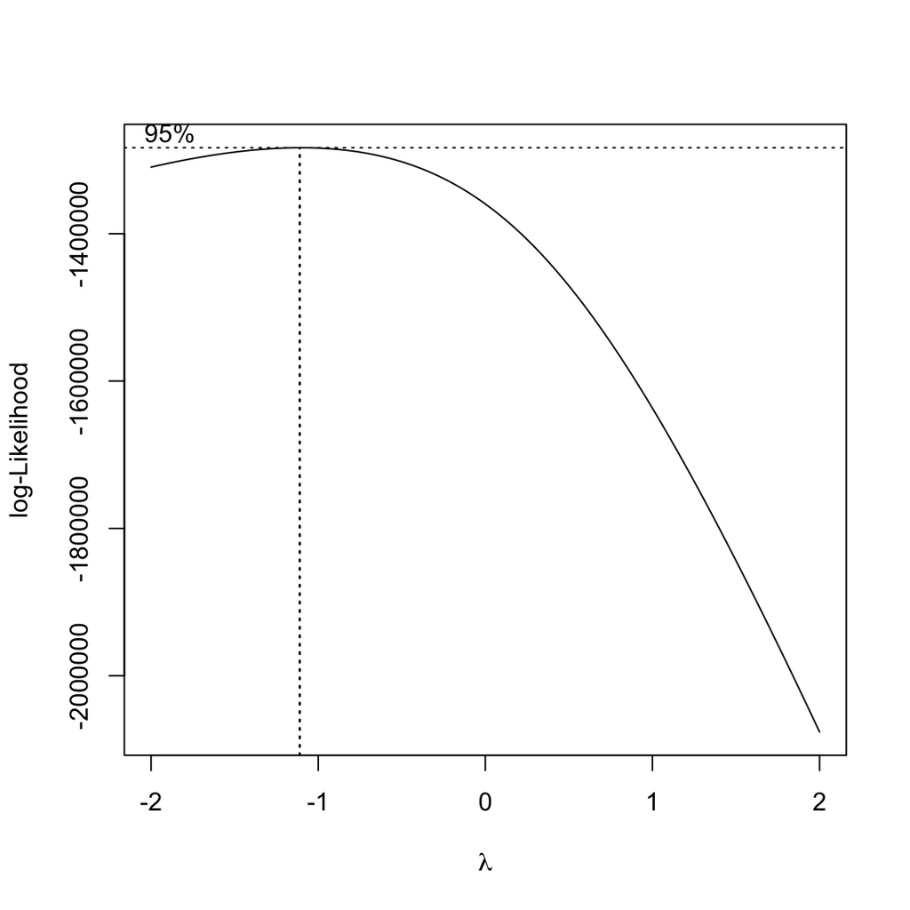

Figure 1: Box-Cox Transformation

```r
# Ensure all values are positive (shift if necessary) to apply box-cox to mental health

#table (ddat2$MentHlth)
min_value <- min(ddat2$MentHlth, na.rm = TRUE)  # Ignore NA values
if (min_value <= 0) {
  ddat2$MentHlth <- ddat2$MentHlth + abs(min_value) + 1
}

library(MASS)
# Perform Box-Cox transformation
boxcox_result <- boxcox(lm(ddat2$MentHlth ~ 1), lambda = seq(-2, 2, 0.1))  # Fit a simple model
```

```r
# Find the optimal lambda
lambda_optimal <- boxcox_result$x[which.max(boxcox_result$y)]
lambda_optimal
```

```
[1] -1.111111
```

```r
#Apply the transformation with the optimal lambda

transformed_data <- if (lambda_optimal == 0) {
  log(ddat2$MentHlth)
} else {
  (ddat2$MentHlth^lambda_optimal - 1) / lambda_optimal
}

pooledData <- data.frame(OriginalData=ddat2$MentHlth, TransformedData=transformed_data)
## Reshape the data - stacking the values and assigning a variable ID.

pooledData$ID <- 1:nrow(pooledData)  # Create an ID variable
LongFormatData <- melt(pooledData, id.vars = "ID")  # Now ID is fixed
```

In **Figure 1**, the Box-Cox transformation is shown an obtimal lambda of -1.11 shows the larger values need to be compressed to help reduce the skewness of the data and make it more symmetric via a negative power transformation.

```r
grp.col = c("navy", "darkred")
names(grp.col) = levels(LongFormatData$variable)

##
ggp = ggplot(LongFormatData,aes(x=value, fill=variable, color = variable)) +
  geom_density(alpha=0.5, na.rm = TRUE) +
  scale_color_manual(values = c("red", "blue")) +
  ggtitle("Distributions of Original and Transformed Data") +
  theme(plot.title = element_text(face = "bold", hjust = 0.5),
        legend.title = element_text(face = "bold", hjust = 0.5),
        theme(legend.position.inside = c(.9, .75)))
#
ggplotly(ggp)   # ggplotly's legend is always on top right by default!
```

[interactive chart not shown]

Figure 2: Original Mental Health Distribution vs Box-Cox Transformation

## 3. Feature Selection

Using domain-knowledge appraoch and waht is known about diabetes and possible factors that are known as risk factors, we made the decision to include the following variables for further analysis - BMI groups, Sex, Smoke, HighBP, PhysHlth, Age, PhysActivity, Education, Income, and MentHlth will be included for analysis. No model-based analysis will be implemented here.

## 4. Feature Creation

To create new variables that improve a model’s predictive performance following the transformation information gained from the feature transformation section and EDA steps, the following feature variables were created.

```r
# bin mental health as featured variable
breaks <- unique(quantile(ddat2$MentHlth, probs = seq(0, 1, length.out = 5), na.rm = TRUE)) # avoids non-unique breaks
ddat2$MentHlth_bin <- cut(ddat2$MentHlth,
                   breaks = breaks,
                   include.lowest = TRUE)


ddat2$MentHlth_bin <- ntile(ddat2$MentHlth, 4)  # Divides into 4 groups
mentab<- table (ddat2$MentHlth_bin)
# Convert to data frame
mentab <- as.data.frame(mentab)
# Rename the column
colnames(mentab)[colnames(mentab) == "Var1"] <- "Groups"
colnames(mentab)[colnames(mentab) == "Freq"] <- "Count"
kable(mentab, format = "html", caption = "Days of poor mental health groups")
```

Table 1: Days of poor mental health groups

| Groups | Count |
| --- | --- |
| 1 | 54500 |
| 2 | 54500 |
| 3 | 54500 |
| 4 | 54500 |

```r
# bin Physical health as featured variable
breaks <- unique(quantile(ddat2$PhysHlth, probs = seq(0, 1, length.out = 5), na.rm = TRUE)) # avoids non-unique breaks
ddat2$PhysHlth_bin <- cut(ddat2$PhysHlth,
                   breaks = breaks,
                   include.lowest = TRUE)


ddat2$PhysHlth_Cat <- ntile(ddat2$PhysHlth_bin, 4)  # Divides into 4 groups
phystab<-table (ddat2$PhysHlth_Cat)
# Convert to data frame
phystab <- as.data.frame(phystab)
#View(phystab)
# Rename the column
colnames(phystab)[colnames(phystab) == "Var1"] <- "Groups"
colnames(phystab)[colnames(phystab) == "Freq"] <- "Count"
#kable(phystab, format = "html", caption = "Days of poor physical health")
```

- Mental and Phsycal Health Quartiles: Because of the box-cox transformation’s failure to generate a normal distribution of the the feature variable, a new feature that bins the variable into 4 groups was created to generate groups that are similar and groups that are not sparse. See Table **1**.
- Income was re-categorized into low, medium-low, medium-high and high groups using the Income distribution during the EDA and feature transforming.

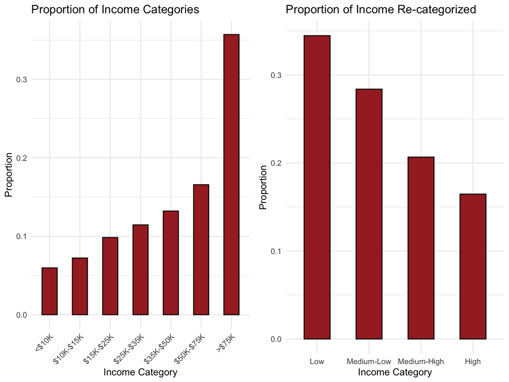

Figure 3: Income Group Comparisons (original vs new)

```r
# Compute Income proportions plot
library(ggplot2)
income_q2<-ggplot(na.omit(ddat2), aes(x = Income_q)) +
  geom_bar(aes(y = after_stat(prop), group = 1), fill = "brown", color = "black", width = 0.5) +
  labs(title = "Proportion of Income Re-categorized",
       x = "Income Category",
       y = "Proportion") +
  theme_minimal()

income_q1<-ggplot(na.omit(ddat2), aes(x = Income)) +
  geom_bar(aes(y = after_stat(prop), group = 1), fill = "brown", color = "black", width = 0.5) +
  labs(title = "Proportion of Income Categories",
       x = "Income Category",
       y = "Proportion") +
  theme_minimal()+
  theme(axis.text.x = element_text(angle = 45, hjust = 1))  # Rotate labels

#table(ddat2$Income_num)

# Arrange plots in a grid (2 columns)
grid.arrange(income_q1, income_q2, ncol = 2)
```

In the bar chart of Income groups shown in **Figure 3**, the feature was engineered such that the groups are reduced and the group proportions are not sparse in each group.

- BMI: The research shows that the BMI is related to Diabetes and can be considered an important feature variable in further analysis. The original variable was normal with outliers at the right tail. Instead of transforming, we made the decision to use the WHO categorization of BMI groups but our data shown very low participants in the under weight group. We made the decision to create a new variable that uses quartiles to group the participants.

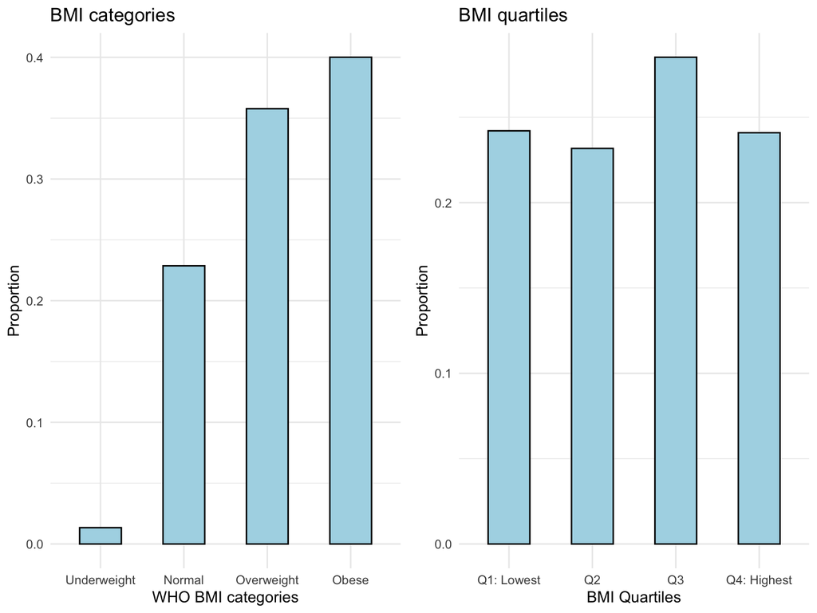

Figure 4: BMI Groups Comparison (original vs new)

```r
# bin BMI into quartiles
ddat2$BMI_Quartile <- cut(ddat2$BMI,
                          breaks = quantile(ddat2$BMI, probs = c(0, 0.25, 0.50, 0.75, 1), na.rm = TRUE),
                          include.lowest = TRUE,
                          labels = c("Q1: Lowest", "Q2", "Q3", "Q4: Highest"))

bmi1 <-ggplot(na.omit(ddat2), aes(x = BMI_Quartile)) +
  geom_bar(aes(y = after_stat(prop), group = 1), fill = "lightblue", color = "black", width = 0.5) +
  labs(title = "BMI quartiles",
       x = "BMI Quartiles",
       y = "Proportion") +
  theme_minimal()

bmi2 <-ggplot(na.omit(ddat2), aes(x = BMI_Cat)) +
  geom_bar(aes(y = after_stat(prop), group = 1), fill = "lightblue", color = "black", width = 0.5) +
  labs(title = "BMI categories",
       x = "WHO BMI categories",
       y = "Proportion") +
  theme_minimal()

# Arrange plots in a grid (2 columns)
grid.arrange(bmi2, bmi1, ncol = 2)
```

```r
#table (ddat2$Education)
```

In the BMI bar chart in **Figure 4**, we see that the underweight had very low counts uing ghe WHO groupings for BMI. On the otherhand, when we used the quartiles, the groups did not contain spares data in the groups as in the original feature BMI variable.

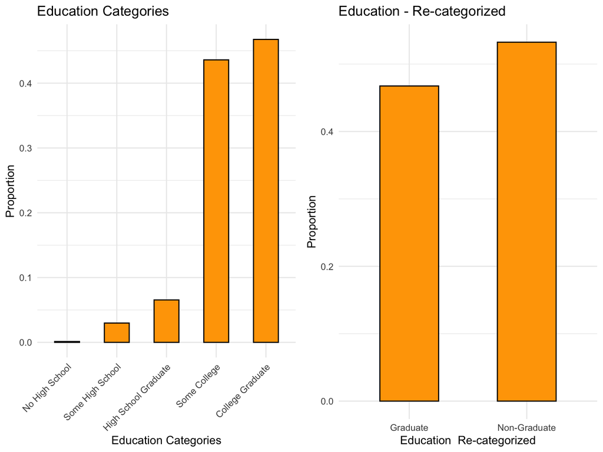

Figure 5: Education Groups comaparison (original vs new)

```r
educ1<-ggplot(na.omit(ddat2), aes(x = Education)) +
  geom_bar(aes(y = after_stat(prop), group = 1), fill = "orange", color = "black", width = 0.5) +
  labs(title = "Education Categories",
       x = "Education Categories",
       y = "Proportion") +
  theme_minimal()+
  theme(axis.text.x = element_text(angle = 45, hjust = 1))  # Rotate labels



ddat2$Education_cat <- case_when(
  ddat2$Education %in% c("No High School", "Some High School", "High School Graduate", "Some College") ~ "Non-Graduate",
  ddat2$Education %in% c("College Graduate") ~ "Graduate",
  TRUE ~ "Unknown"
)
educ2<-ggplot(na.omit(ddat2), aes(x = Education_cat)) +
  geom_bar(aes(y = after_stat(prop), group = 1), fill = "orange", color = "black", width = 0.5) +
  labs(title = "Education - Re-categorized",
       x = "Education  Re-categorized",
       y = "Proportion") +
  theme_minimal()


# Arrange plots in a grid (2 columns)
grid.arrange(educ1, educ2, ncol = 2)
```

- Education: Similarly, Edcuation was re-categorized by grouping then into no gradate education and graduates. We notice sparse data in the original variable while the newly created variable that re-categorized the education variable shown more similar groups with the variable.
- Age: The original Age variable had multiple groups that had sparsed groups. Age was re-categorized into 3 groups to ensure these groups did not have severe imbalnces.

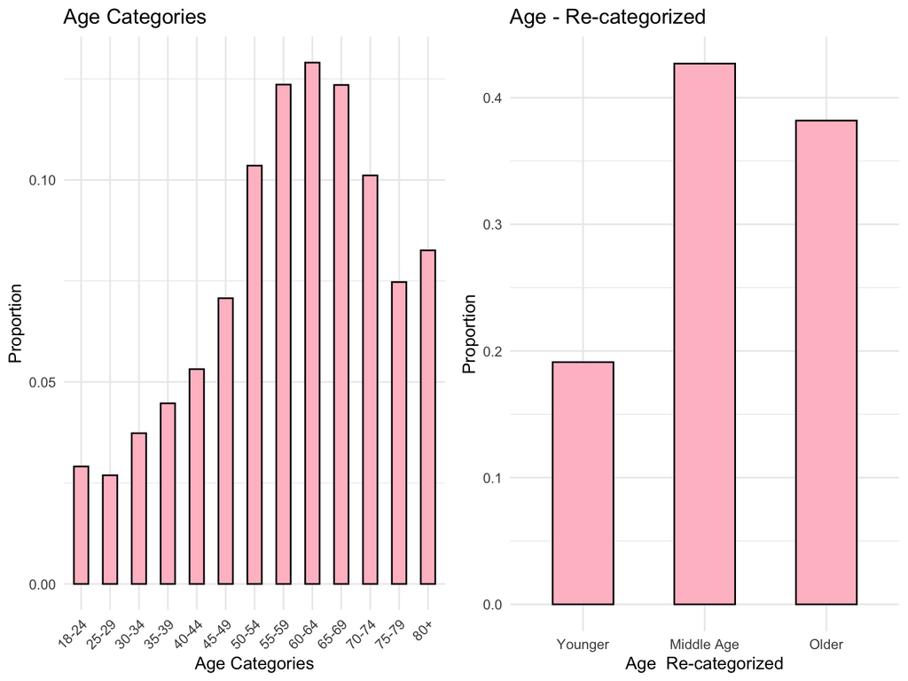

Figure 6: Age group Comparison (original vs new)

```r
age1<-ggplot(na.omit(ddat2), aes(x = Age)) +
  geom_bar(aes(y = after_stat(prop), group = 1), fill = "pink", color = "black", width = 0.5) +
  labs(title = "Age Categories",
       x = "Age Categories",
       y = "Proportion") +
  theme_minimal()+
  theme(axis.text.x = element_text(angle = 45, hjust = 1))  # Rotate labels



age2<-ggplot(na.omit(ddat2), aes(x = Age_grp)) +
  geom_bar(aes(y = after_stat(prop), group = 1), fill = "pink", color = "black", width = 0.5) +
  labs(title = "Age - Re-categorized",
       x = "Age  Re-categorized",
       y = "Proportion") +
  theme_minimal()

# Arrange plots in a grid (2 columns)
grid.arrange(age1, age2, ncol = 2)
```

In the Age Group bar chart in **Figure 6**, we see that the re-categorized groups will ensure that underrepresented age groups are not present anymore. This will help in other analysis like aid in model interpretability.

In summary, these approaches will enhcance better predictive ability and lead to a good model that generalizes well. It will also reduce the risk of over fitting models since they will be built more on generic groups than specific ones. They will also reduce data imbalance in these variables.